# Assortativity Tutorial: Trade Networks

# 4) Visualize assortativity coefficients

Leeds (1999) finds empirical support for the hypothesis that democracies are less likely to cheat and less likely to enter agreements with risk of cheating. Hence democracies tend to cooperate with other democracies. Bliss & Russett (1998) find support of greater trade cooperation between democracies.

It is interesting to see the distribution of edge weights (% of total weight) between each polity group.

We can use the mixing matrix that is returned from using **“assortment.discrete”** function from **‘assortnet’** to visualize the edge weights by categories. I only present democracy to democracy and autocracy to autocracy relationships in **Figure 5**.

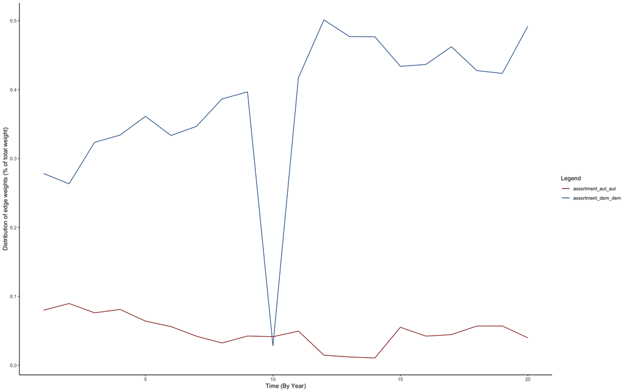